# Quality of Contact Metric Notebook

```r
# Libraries
library(tidyverse)
library(dplyr)
library(magrittr)
library(patchwork)
library(ggthemes)
library(xgboost)
library(Boruta)
library(psych)
library(fastDummies)
library(tidymodels)
library(readr)
```

```r
# Setting seed for reproducibility
set.seed(123)
```

```r
# Reading in data
all_bip <- readr::read_csv("all_bip.csv")
```

# Data Exploration and Cleaning

My objectives in exploring and cleaning the dataset were to better understand the kinds of patterns and features that might be most relevant to building a quality of contact model and to ensure that there are no obvious problems with the data quality. By exploring the data with various analyses and visualizations, I was able to achieve both goals simultaneously.

Having previously worked with similar datasets, I started my data exploration by looking for ‘No Nulls.’ ‘No Nulls’ batted balls occur when the Trackman system is unable to capture the ball after contact (usually because it was either a sky-high pop-up or a grounder beat into the ground). The stringer at the stadium then records where the ball was fielded and then the missing exit velocity, launch angle, and other variables are then put in retroactively. This means that I can’t be sure that the data is accurate, so I remove all ‘No Nulls’ entries from the dataset to eliminate potential biases later when I train my model.

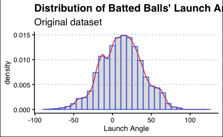

```r
ggplot(all_bip, aes(x = angle)) +
  geom_density(color = "red") + geom_histogram(aes(y=..density..), color = "royalblue", alpha = .2) +
  labs(title = "Distribution of Batted Balls' Launch Angle", subtitle = "Original dataset", x = "Launch Angle") + ggthemes::theme_clean()
```

In this graph we can see both the density and histogram distributions of launch angle in the dataset. After previously working with this type of data, it is clear to me that this dataset has some abnormalities in it. Most notably, there is a local peak around -20 to -10 degrees that wouldn’t normally be present. Typically, we should expect a fairly normal distribution of batted balls’ launch angle with a dataset of this size.

**Investigating ‘No Nulls’**

```r
ev_la_dir_combos <- all_bip %>%
  group_by(exit_speed, angle, direction) %>%
  summarise(num = n()) %>%
  arrange(desc(num))

ev_la_dir_combos
```

| exit_speed | angle | direction | num |
| --- | --- | --- | --- |
| NA | NA | NA | 104 |
| 49.42 | 121.42 | -31.60 | 7 |
| 39.77 | -43.33 | -20.56 | 5 |
| 75.08 | -22.13 | -0.33 | 4 |
| 82.21 | -15.22 | -35.19 | 4 |
| 82.29 | -15.14 | -13.97 | 4 |
| 39.46 | -48.73 | -0.77 | 3 |
| 39.64 | -45.56 | -22.65 | 3 |
| 39.94 | -40.42 | -28.19 | 3 |
| 70.00 | 69.90 | 25.46 | 3 |

[output cut: 990 more lines]

The original dataset has 122,893 batted balls. From the above grouping, we can see that there are 122,378 unique combinations of exit speed, angle, and direction. That corresponds to 99.58% of the combinations being unique.

```r
non_unique_combos <- ev_la_dir_combos %>%
  filter(num > 1)

non_unique_combos
```

| exit_speed | angle | direction | num |
| --- | --- | --- | --- |
| NA | NA | NA | 104 |
| 49.42 | 121.42 | -31.60 | 7 |
| 39.77 | -43.33 | -20.56 | 5 |
| 75.08 | -22.13 | -0.33 | 4 |
| 82.21 | -15.22 | -35.19 | 4 |
| 82.29 | -15.14 | -13.97 | 4 |
| 39.46 | -48.73 | -0.77 | 3 |
| 39.64 | -45.56 | -22.65 | 3 |
| 39.94 | -40.42 | -28.19 | 3 |
| 70.00 | 69.90 | 25.46 | 3 |

[output cut: 358 more lines]

```r
non_unique_all_combos <- all_bip %>%
  group_by(exit_speed, angle, direction, distance, bearing) %>%
  summarise(num = n()) %>%
  filter(num > 1)

non_unique_all_combos
```

| exit_speed | angle | direction | distance | bearing | num |
| --- | --- | --- | --- | --- | --- |
| 39.35 | -50.48 | -0.42 | 3.67 | -0.42 | 2 |
| 39.45 | -48.86 | -11.12 | 4.76 | -11.12 | 2 |
| 39.46 | -48.73 | -0.77 | 4.85 | -0.77 | 3 |
| 39.48 | -48.35 | -0.75 | 5.10 | -0.75 | 2 |
| 39.52 | -47.70 | -8.14 | 5.54 | -8.14 | 2 |
| 39.54 | -47.32 | 4.72 | 5.80 | 4.72 | 2 |
| 39.58 | -46.57 | 13.17 | 6.31 | 13.17 | 2 |
| 39.58 | -46.53 | -20.55 | 6.33 | -20.55 | 2 |
| 39.59 | -46.41 | -16.27 | 6.41 | -16.27 | 2 |
| 39.60 | -46.35 | 22.99 | 6.46 | 22.99 | 2 |

[output cut: 340 more lines]

The combination of exit_speed, angle, direction, distance, and bearing show that there are 350 non-unique combinations compared to the 368 non-unique combinations seen earlier when combining exit_speed, angle, and direction.

I decided to look more into the 18 different combinations that are present when grouping by exit_speed, angle, and direction but are not present when grouping by exit_speed, angle, direction, distance, and bearing.

```r
diff_in_groupings <- dplyr::anti_join(non_unique_combos, non_unique_all_combos, by = c("exit_speed", "angle", "direction"))

for(i in 1:nrow(diff_in_groupings)) {
  temp <- all_bip %>%
    filter(exit_speed == diff_in_groupings$exit_speed[i] & angle == diff_in_groupings$angle[i] & direction == diff_in_groupings$direction[i]) %>%
    select(c(exit_speed, angle, direction, distance, bearing))
  print(temp)
}
```

| exit_speed | angle | direction | distance | bearing |
| --- | --- | --- | --- | --- |
| 71.01 | 67.73 | 21.37 | 106.36 | 21.37 |
| 71.01 | 67.73 | 21.37 | 106.35 | 21.37 |

| exit_speed | angle | direction | distance | bearing |
| --- | --- | --- | --- | --- |
| 71.39 | 66.91 | -66.26 | 111.42 | -66.26 |
| 71.39 | 66.91 | -66.26 | 111.41 | -66.26 |

| exit_speed | angle | direction | distance | bearing |
| --- | --- | --- | --- | --- |
| 71.89 | 65.85 | -55.91 | 118.00 | -55.91 |
| 71.89 | 65.85 | -55.91 | 117.99 | -55.91 |

| exit_speed | angle | direction | distance | bearing |
| --- | --- | --- | --- | --- |
| 73.29 | 62.82 | -27.64 | 136.67 | -27.64 |
| 73.29 | 62.82 | -27.64 | 136.68 | -27.64 |

| exit_speed | angle | direction | distance | bearing |
| --- | --- | --- | --- | --- |
| 73.43 | 62.52 | -59.31 | 138.51 | -59.31 |
| 73.43 | 62.52 | -59.31 | 138.52 | -59.31 |

| exit_speed | angle | direction | distance | bearing |
| --- | --- | --- | --- | --- |
| 73.73 | 61.87 | -27.58 | 142.55 | -27.58 |
| 73.73 | 61.87 | -27.58 | 142.54 | -27.58 |

| exit_speed | angle | direction | distance | bearing |
| --- | --- | --- | --- | --- |
| 74.38 | 60.48 | 57.26 | 151.15 | 57.26 |
| 74.38 | 60.48 | 57.26 | 151.14 | 57.26 |

| exit_speed | angle | direction | distance | bearing |
| --- | --- | --- | --- | --- |
| 76.29 | 56.36 | 33.8 | 176.57 | 33.8 |
| 76.29 | 56.36 | 33.8 | 176.58 | 33.8 |

| exit_speed | angle | direction | distance | bearing |
| --- | --- | --- | --- | --- |
| 76.6 | -20.66 | -19.36 | 10.62 | -19.36 |
| 76.6 | -20.66 | -19.36 | 10.61 | -19.36 |

| exit_speed | angle | direction | distance | bearing |
| --- | --- | --- | --- | --- |
| 76.69 | -20.57 | 22.42 | 10.81 | 22.42 |
| 76.69 | -20.57 | 22.42 | 10.82 | 22.42 |

| exit_speed | angle | direction | distance | bearing |
| --- | --- | --- | --- | --- |
| 77.09 | -20.19 | -0.45 | 11.72 | -0.45 |
| 77.09 | -20.19 | -0.45 | 11.71 | -0.45 |

| exit_speed | angle | direction | distance | bearing |
| --- | --- | --- | --- | --- |
| 77.56 | -19.73 | -1.7 | 12.78 | -1.7 |
| 77.56 | -19.73 | -1.7 | 12.79 | -1.7 |

| exit_speed | angle | direction | distance | bearing |
| --- | --- | --- | --- | --- |
| 77.69 | -19.61 | 3.37 | 13.07 | 3.37 |
| 77.69 | -19.61 | 3.37 | 13.06 | 3.37 |

| exit_speed | angle | direction | distance | bearing |
| --- | --- | --- | --- | --- |
| 80.08 | -17.28 | -19 | 18.47 | -19 |
| 80.08 | -17.28 | -19 | 18.46 | -19 |

| exit_speed | angle | direction | distance | bearing |
| --- | --- | --- | --- | --- |
| 81.68 | -15.74 | -27.89 | 22.05 | -27.89 |
| 81.68 | -15.74 | -27.89 | 22.06 | -27.89 |

| exit_speed | angle | direction | distance | bearing |
| --- | --- | --- | --- | --- |
| 83.13 | -14.33 | -28.04 | 25.32 | -28.04 |
| 83.13 | -14.33 | -28.04 | 25.33 | -28.04 |

| exit_speed | angle | direction | distance | bearing |
| --- | --- | --- | --- | --- |
| 83.23 | 36.91 | 28.89 | 274.63 | 28.89 |
| 83.23 | 36.91 | 28.89 | 274.64 | 28.89 |

| exit_speed | angle | direction | distance | bearing |
| --- | --- | --- | --- | --- |
| 85.49 | -12.04 | 13.31 | 30.63 | 13.31 |
| 85.49 | -12.04 | 13.31 | 30.64 | 13.31 |

From this we can see that in these 18 different combinations the bearings are equal within the grouping, but the distance is different. The difference in distance in all combinations is just .01. With a difference so small, and the four other variables all equal, it is reasonable to keep these 18 combinations within the original 368 of non-unique combinations.

I decided to simplify this exploration by just looking at the non-unique combinations of exit speed and launch angle.

```r
exit_angle_group <- all_bip %>%
  group_by(exit_speed, angle) %>%
  summarise(num = n()) %>%
  filter(num > 1) %>%
  arrange(desc(num))
exit_angle_group
```

| exit_speed | angle | num |
| --- | --- | --- |
| NA | NA | 104 |
| 78.05 | -19.25 | 11 |
| 83.18 | -14.28 | 11 |
| 82.88 | -14.57 | 10 |
| 73.13 | 63.17 | 9 |
| 82.18 | -15.25 | 9 |
| 83.50 | -13.97 | 9 |
| 84.22 | -13.27 | 9 |
| 74.07 | 61.15 | 8 |
| 76.94 | -20.33 | 8 |

[output cut: 990 more lines]

Here, we see that there are 2,721 non-unique combinations of exit speed and launch angle. Those 2,721 combinations represent 8,022 batted balls making up about 6.5% of the entire dataset. That represented too much of the dataset for me to be comfortable with removing all of those instances.

I decided to increase the minimum number of instances of non-unique exit speed and launch angle combinations to be greater than or equal to five instances. Removing only combinations that had more than five or more observations was a bit arbitrary. Originally, I wanted to remove all non-unique combination observations, but that represented too much of the dataset. I wanted to remove those instances because in this dataset there are over 7,500 unique exit speed values and over 13,500 unique launch angle values. The probability of having two batted balls with the same exit speed and launch angle is just incredibly low. However, I had to balance keeping enough observations for modeling and wanting to protect the dataset from potential biases.

```r
exit_angle_group_5 <- exit_angle_group %>%
  filter(num > 4)
exit_angle_group_5
```

| exit_speed | angle | num |
| --- | --- | --- |
| NA | NA | 104 |
| 78.05 | -19.25 | 11 |
| 83.18 | -14.28 | 11 |
| 82.88 | -14.57 | 10 |
| 73.13 | 63.17 | 9 |
| 82.18 | -15.25 | 9 |
| 83.50 | -13.97 | 9 |
| 84.22 | -13.27 | 9 |
| 74.07 | 61.15 | 8 |
| 76.94 | -20.33 | 8 |

[output cut: 299 more lines]

Removing observations from a dataset is not something to do lightly. However, I felt it was necessary to remove the observations with five or more instances of the same exit speed and launch angle. As I said above, the probability of this occurring is so highly unlikely, that these batted balls must have been ‘no nulls’ and their exit speed and launch angles retroactively imputed. When looking at the launch angles of these combinations with five or more observations, there is a gap visible. The launch angle has a range of -45.35 to -10.82 and then the next launch angle is at 54.82 going to 70.18 (with seven instances of 121.42 launch angle, which is a major outlier). We know (https://tht.fangraphs.com/43416-2/) that Trackman has issues handling grounders and pop-ups and this further reinforces that claim. With removing these non-unique observations, we can be sure that the dataset only contains only measured batted balls.

```r
#Removing 'No Nulls'
bip_wo_exit_angle_group_5 <- dplyr::anti_join(all_bip, exit_angle_group_5, by = c("exit_speed", "angle"))
```

Here, we can see the differences in launch angle distribution from the original and cleaned datasets.

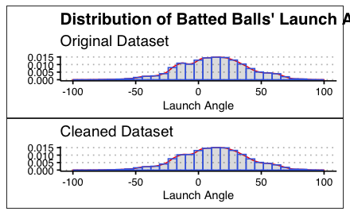

```r
original_dataset <- ggplot(all_bip, aes(x = angle)) +
  geom_density(color = "red") + geom_histogram(aes(y=..density..), color = "royalblue", alpha = .2) +
  xlab("Launch Angle") +
  ggtitle("Distribution of Batted Balls' Launch Angle") +
  labs(subtitle = "Original Dataset", y = "")+ xlim(-100, 100) + theme_clean()

cleaned_dataset <- ggplot(bip_wo_exit_angle_group_5, aes(x = angle)) +
  geom_density(color = "red") + geom_histogram(aes(y=..density..), color = "royalblue", alpha = .2) +
  xlab("Launch Angle") +
  labs(subtitle = "Cleaned Dataset", y = "") + xlim(-100, 100) + theme_clean()

(original_dataset) / (cleaned_dataset)
```

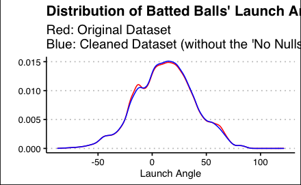

```r
ggplot(data = all_bip, aes(x=angle)) +
  geom_density(color = "red") +
  geom_density(data = bip_wo_exit_angle_group_5, color = "blue") +
  xlab("Launch Angle") +
  ggtitle("Distribution of Batted Balls' Launch Angle") +
  labs(subtitle = "Red: Original Dataset\nBlue: Cleaned Dataset (without the 'No Nulls')",y = "") + theme_clean()
```

From these two previous graphs we can see the differences between the original and cleaned dataset. Most notably, the local peak at around -20 to -10 is no longer present. The cleaned distribution much more closely resembles a normal distribution, with more observations being present in the center. As I mentioned above, having access to more information about each batted ball (i.e., video of the play) would allow me to dive more into the ‘No Nulls’ issue and see if there is more to be done in terms of cleaning the dataset.

**More Dataset Cleaning**

```r
all_bip_cleaned <- bip_wo_exit_angle_group_5
```

```r
# adding count feature and removing two instances of impossible counts (4-1, 0-3)
all_bip_cleaned %<>%
  mutate(count = paste0(balls, "-", strikes)) %>%
  select(-c("balls", "strikes")) %>%
  filter(!count %in% c('4-1', '0-3'))
```

```r
# changing features to factors in order to create more graphics for data exploration
all_bip_cleaned$count <- as.factor(all_bip_cleaned$count)
all_bip_cleaned$batter_side <- as.factor(all_bip_cleaned$batter_side)
all_bip_cleaned$pitcher_throws <- as.factor(all_bip_cleaned$pitcher_throws)
all_bip_cleaned$tagged_pitch_type <- as.factor(all_bip_cleaned$tagged_pitch_type)
all_bip_cleaned$hit_type <- as.factor(all_bip_cleaned$hit_type)
all_bip_cleaned$play_result <- as.factor(all_bip_cleaned$play_result)
```

## Data Exploration

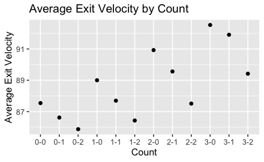

```r
all_bip_cleaned %>%
  group_by(count) %>%
  summarise(avg_ev = mean(exit_speed, na.rm=T),
            num = n()) %>%
  ggplot(aes(x = count, y = avg_ev)) +
  geom_point() + labs(x = "Count", y = "Average Exit Velocity", title = "Average Exit Velocity by Count")
```

Next, I wanted to explore the factors that most contribute to “quality contact”. This chart shows that the count does have an effect on the exit velocity of a batted ball. Also, a cool pattern emerges as the average exit velocity increases for every additional ball in the count and decreases for every additional strike in the count.

Next, looking into how the count affects average launch angle.

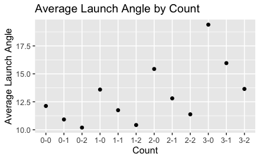

```r
all_bip_cleaned %>%
  group_by(count) %>%
  summarise(avg_la = mean(angle, na.rm=T),
            num = n()) %>%
  ggplot(aes(x = count, y = avg_la)) +
  geom_point() + labs(x = "Count", y = "Average Launch Angle", title = "Average Launch Angle by Count")
```

Here, we see a similar pattern as above with average exit speed.

Next, I examined the relationship between pitcher and batter handedness and the effect on exit speed and launch angle.

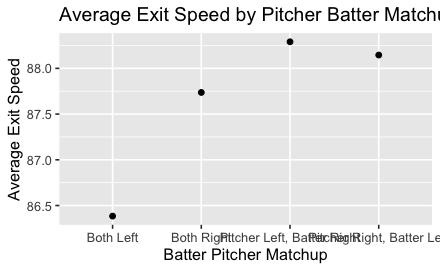

```r
all_bip_cleaned %>%
  group_by(batter_side, pitcher_throws) %>%
  summarise(avg_ev = mean(exit_speed, na.rm=T)) %>%
  mutate(`Batter Pitcher Matchup` = ifelse(batter_side == "Right" & pitcher_throws == "Right", "Both Right",
                                         ifelse(batter_side == "Right" & pitcher_throws == "Left", "Pitcher Right, Batter Left",
                                                ifelse(batter_side == "Left" & pitcher_throws == "Right", "Pitcher Left, Batter Right",
                                                       ifelse(batter_side == "Left" & pitcher_throws == "Left", "Both Left", NA))))) %>%
  ggplot(aes(y = avg_ev, x = `Batter Pitcher Matchup`)) +
  geom_point() + labs(x = "Batter Pitcher Matchup", y = "Average Exit Speed", title = "Average Exit Speed by Pitcher Batter Matchup")
```

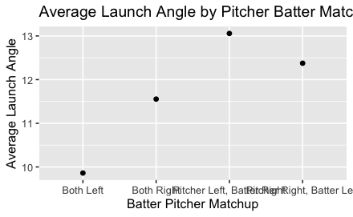

```r
all_bip_cleaned %>%
  group_by(batter_side, pitcher_throws) %>%
  summarise(avg_la = mean(angle, na.rm=T)) %>%
  mutate(`Batter Pitcher Matchup` = ifelse(batter_side == "Right" & pitcher_throws == "Right", "Both Right",
                                         ifelse(batter_side == "Right" & pitcher_throws == "Left", "Pitcher Right, Batter Left",
                                                ifelse(batter_side == "Left" & pitcher_throws == "Right", "Pitcher Left, Batter Right",
                                                       ifelse(batter_side == "Left" & pitcher_throws == "Left", "Both Left", NA))))) %>%
  ggplot(aes(y = avg_la, x = `Batter Pitcher Matchup`)) +
  geom_point() + labs(x = "Batter Pitcher Matchup", y = "Average Launch Angle", title = "Average Launch Angle by Pitcher Batter Matchup")
```

From this preliminary analysis, there is a noticeable effect of batter-pitcher matchup on average exit velocity and launch angle. It seems that hitters perform better (in terms of average exit velocity and launch angle) if the batter and pitcher have different handedness. Pitchers tend to benefit if the batter has the same handedness as they do. This follows the basic intuition of platoon advantages.

Next, I wanted to explore whether there was an interaction effect between the count and batter-pitcher matchup.

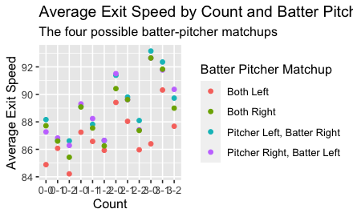

```r
all_bip_cleaned %>%
  group_by(count, batter_side, pitcher_throws) %>%
  summarise(avg_ev = mean(exit_speed, na.rm=T),
            num = n()) %>%
  mutate(`Batter Pitcher Matchup` = ifelse(batter_side == "Right" & pitcher_throws == "Right", "Both Right",
                                         ifelse(batter_side == "Right" & pitcher_throws == "Left", "Pitcher Right, Batter Left",
                                                ifelse(batter_side == "Left" & pitcher_throws == "Right", "Pitcher Left, Batter Right",
                                                       ifelse(batter_side == "Left" & pitcher_throws == "Left", "Both Left", NA))))) %>%
  ggplot(aes(x = count, y = avg_ev, color = `Batter Pitcher Matchup`)) +
  geom_point() + labs(x = "Count", y = "Average Exit Speed", title = "Average Exit Speed by Count and Batter Pitcher Matchup",
                      subtitle = "The four possible batter-pitcher matchups")
```

# Methodology and Design Decisions

To create a quality of contact metric, I created a multi-class classification model that aims to predict the play result using a XGBoost model. XGBoost is a decision tree based ensemble supervised machine learning algorithm that uses a gradient boosting framework. Gradient boosting is a case of boosting where errors are minimized by gradient descent and applies the principle of boosting weak learners. The rationale for using XGBoost lies in its easy to understand nature and the structure and size of the data. Decision trees for classifications are easy to interpret on a fundamental level. A basic decision tree, for example just a tree stump, visualized it is easy to see the rationale for the classification. Since this dataset is relatively large (over 100,000 observations) and is tabular data, gradient boosting machines (GBMs), specifically XGBoost seems like a fine choice for this problem. Also, GBMs are non-parametric models that are suitable for this non-linear data.

For my modeling, I decided on using the play result as the response variable. The play result (out, single, double, triple, homerun, sacrifice, fielder’s choice, and error) is a good starting place for measuring quality of contact. If we are just looking at grading quality of contact based on the result of the batted ball then we know that a homerun is better than a triple which is better than a double and so on. This metric provides a broadly accepted way to rank the quality of a batted ball. Generally speaking, hitting a ball harder (more exit speed) is better than hitting a ball softer. However, it’s important to include the launch angle when using exit speed. A batter would much rather hit a ball 105 mph at 25 degrees than a ball 125 mph at -10 degrees. There are exceptions, but in the aggregate we know that homeruns have the best combination of exit speed and launch angle. However, there is more to assessing quality of contact than just exit speed and launch angle, such as launch direction, bearing, and distance. Each of the metrics individually can provide some insight about the quality of contact, but when taken together it quickly becomes intractable to rank every possible combination. From this, I felt that all of these metrics were best captured and ranked by the play result.

**Feature Selection**

Even though the Boruta indicated that all features were important, I decided to not include pa_of_inning, pitch_of_ab, outs, and hit_type in my modeling. The decision to not include the plate appearance of the inning was because I didn’t think that a batter should gain or lose credit for quality of contact based on when the plate appearance occurred in an inning. Additionally, outs were not included for the same reason. The pitch number of the at-bat was not included because the count was already present in the modeling and including both felt redundant as the count is an accurate representation of how many pitches were in the at-bat. In the case of multiple foul balls, where the number of pitches is greater than the sum of balls and strikes, the hitter will have the same number of strikes. A homerun hit on a 3-0 count is very different than a 0-2 count. Assuming the quality of contact is the same, a batter should get more credit for the ball hit on 0-2 than 3-0. A batter shouldn’t get more credit for a batted ball that was hit on the fifth pitch of an at bat versus the tenth pitch. Similarly, hit type was not included because the information gained from that feature is already present in the angle variable.

**Feature Engineering**

For the purposes of simplifying the XGBoost modeling, I considered change-ups and splitters to be the same. They were both grouped together as change-ups. I also grouped ‘Undefined’ and knuckleball pitch-types into the same category as ‘Other.’

Earlier, I also created one feature for the count, combining the strike and ball features into one variable.

There are four categorical variables that were included in the model: batter_side, pitcher_throws, tagged_pitch_type, and count. As mentioned above, since XGBoost can only handle numeric variables, I changed each of those variables into a numeric one by creating dummy variables. For example, for both batter_side and pitcher_throws there will be one new column batter_side_right and pitcher_throws_right, respectively. Those two columns would equal “1” if the pitcher or batter throws right, and 0 otherwise. There were seven dummy columns created for tagged_pitch_type (cutter, curveball, sinker, slider, fastball, change-up, and other), and twelve columns for count.

*Feature Selection*

```r
#all_bip_cleaned_boruta <- Boruta(play_result ~ pa_of_inning + pitch_of_pa + batter_side + pitcher_throws + outs + tagged_pitch_type + exit_speed + angle + direction + distance + bearing + count, data = all_bip_cleaned)
print(all_bip_cleaned_boruta)
```

```
Boruta performed 11 iterations in 52.96874 mins.
 12 attributes confirmed important: angle, batter_side, bearing, count, direction and 7 more;
 No attributes deemed unimportant.
```

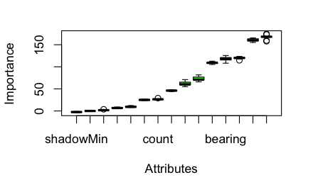

```r
plot(all_bip_cleaned_boruta)
```

*Feature Engineering*

```r
# Make a new dataset that merges outs with fielders choice, sac, and error.
xgb_data <- all_bip_cleaned %>%
  mutate(play_result = case_when(
      play_result %in% c("Out", "FieldersChoice", "Sacrifice", "Error") ~ "Out",
      play_result == "Single" ~ "Single",
      play_result == "Double" ~ "Double",
      play_result == "Triple" ~ "Triple",
      play_result == "HomeRun" ~ "HomeRun",
      play_result == "Undefined" ~ "Undefined")
    )

# remove undefined play_results
xgb_data %<>% filter(!play_result == "Undefined")

# turn play_result into a factor for easy label encoding
xgb_data$play_result <- as.factor(xgb_data$play_result)

# XGBoost labels have to be zero-indexed
xgb_data$play_result_ec <- as.integer(xgb_data$play_result) - 1

xgb_data <- xgb_data %>%
  mutate(batter_side_right = ifelse(batter_side == "Right", 1, 0)) %>%
  mutate(pitcher_throws_right = ifelse(pitcher_throws == "Right", 1, 0)) %>%
  dplyr::select(-c("batter_side", "pitcher_throws"))

xgb_data %<>%
  mutate(tagged_pitch_type = case_when(
      tagged_pitch_type %in% c("ChangeUp", "Splitter") ~ "ChangeUp",
      tagged_pitch_type %in% c("Other", "Undefined", "Knuckleball") ~ "Other",
      tagged_pitch_type == "Fastball" ~ "Fastball",
      tagged_pitch_type == "Slider" ~ "Slider",
      tagged_pitch_type == "Sinker" ~ "Sinker",
      tagged_pitch_type == "Curveball" ~ "Curveball",
      tagged_pitch_type == "Cutter" ~ "Cutter")
    )
# dummy variables for pitch type
xgb_data <- fastDummies::dummy_cols(xgb_data,select_columns = c("tagged_pitch_type"))

# dummy variables for count
xgb_data <- fastDummies::dummy_cols(xgb_data,select_columns = c("count"))
```

# Analysis/Model Selection

Once the data was prepared for XGBoost modeling, I divided the cleaned dataset into two datasets: train and test. I used a stratified 70/30 split to ensure that the train and test datasets would be split evenly by the response variable, play result.

*XGBoost Data Formatting*

```r
# create indecies for splitting (need to use a specific column from df for it to run)
train_index <- createDataPartition(y = xgb_data$play_result_ec, p = .7, list = FALSE) %>% as.vector()

# split into train and test
train <- xgb_data[train_index,]
test <- xgb_data[-train_index,]

# need a vector of response variable (play result)
vec_label_train <- train$play_result_ec
# removing features from the datasets that are not going to be used in the model. tagged_pitch_type and count weren't included because of the newly created dummy variables. play_result and play_result_ec also not included because that information is in the label vector.
train_data <- as.matrix(train %>%  dplyr::select(-c("pa_of_inning", "pitch_of_pa", "outs", "hit_type", "play_result", "play_result_ec",
                                                       "tagged_pitch_type", "count")))

vec_label_test <- test$play_result_ec
test_data <- as.matrix(test %>% dplyr::select(-c("pa_of_inning", "pitch_of_pa", "outs", "hit_type", "play_result", "play_result_ec",
                                                    "tagged_pitch_type", "count")))

# convert the train and test into xgb.DMatrix
x_train = xgboost::xgb.DMatrix(data = train_data, label = vec_label_train)
x_test = xgboost::xgb.DMatrix(data = test_data, label = vec_label_test)
```

## Baseline Model

I started the modeling by doing a simple 10-fold cross-validation to determine the appropriate number of iterations to use in a baseline XGBoost model. There were two main choices I made in the XGBoost modeling. I decided to use multi:softprob as the objective of the model with mlogloss evaluation metric. multi:softprob returns the probability of each observation being a member of each class. There are five classes of the response variable (Out, Single, Double, Triple, and Homerun). I made this choice because you can gain more information about each batted ball knowing the probability of it belonging to each class rather than the model returning which class has the maximum probability. The evaluation metric is used for validation data in both the cross-validation and XGBoost modeling for both early stopping and model evaluation. mlogloss is the loss function used in multinomial logistic regression and is defined as the negative log-likelihood of a logistic model that returns probabilities for its training data. The baseline model also has no hyperparameters specified, meaning that all of those parameters are their default values. I decided to run a baseline model in order to compare it with a hyperparameter tuned model. A baseline model is a good place to start as it is fast and easy to run, and we can’t tell if a future model is any good in a vacuum. Meaning that even if a model returns a 95% accuracy we don’t know if the model is any good because there theoretically could be a model with different hyperparameters that returns a 99% accuracy.

*XGBoost Baseline Modeling*

```r
baseline_cv <- xgboost::xgb.cv(params = list(objective = "multi:softprob", eval_metric = c("mlogloss"), num_class = 5), data = x_train, nrounds = 2500, early_stopping_rounds = 10, nfold=10, stratified = T)

base_mod <- xgboost::xgboost(params = list(objective = "multi:softprob", eval_metric = c("mlogloss"), num_class = 5), data = x_train, nrounds = baseline_cv$best_ntreelimit)
```

*Predictions Using the Baseline Model*

```r
xgb.pred_base = predict(base_mod, x_test, reshape=T)
xgb.pred_base = as.data.frame(xgb.pred_base)
colnames(xgb.pred_base) = levels(xgb_data$play_result)

xgb.pred_base <- xgb.pred_base[, c(3, 4, 1, 5, 2)]

preds_base <- test
preds_base$out.prob <- xgb.pred_base[,1]
preds_base$single.prob <- xgb.pred_base[,2]
preds_base$double.prob <- xgb.pred_base[,3]
preds_base$triple.prob <- xgb.pred_base[,4]
preds_base$hr.prob <- xgb.pred_base[,5]

max_prob_v2 <- colnames(xgb.pred_base)[apply(xgb.pred_base,1,which.max)]

preds_base$max.prob <- max_prob_v2

preds_base$pred.right <- ifelse(preds_base$max.prob == preds_base$play_result, "yes", "no")
preds_base$pred.right <- as.factor(preds_base$pred.right)

sum(preds_base$max.prob == preds_base$play_result) / nrow(preds_base) #v1 acc = 82ish, v2 acc = 82ish. v2 slightly higher
```

```
[1] 0.8304878
```

We can see that the baseline model, fit on the train dataset, had an accuracy of 83% on the test dataset.

## Hyperparameter Tuning

I used a Latin hypercube for hyperparameter tuning. The Latin hypercube is a space-filling design that aims at filling the hyperparameter space as well as possible, so it’s not necessary to run a model for every unique hyperparameter combination. The Latin hypercube creates 30 rows of different combinations of six hyperparameters (eta, gamma, subsample, colsample_bytree, max_depth, and min_child_weight). Then each combination was run through a 10-fold cross-validation using early stopping rounds to see which combination performed the best on the train set. The best performing combination was then used in one final XGBoost model to compare with the baseline model.

*XGBoost Hyperparameter Tuning*

```r
grid <- dials::grid_latin_hypercube(
  dials::finalize(dials::mtry(), train_data),
  dials::min_n(),
  dials::tree_depth(),
  dials::learn_rate(),
  dials::loss_reduction(),
  sample_size = dials::sample_prop(),
  size = 30
)

grid <- grid %>%
  mutate(
    learn_rate = .225 + .1 * ((1 : nrow(grid)) / nrow(grid)),
    # has to be between 0 and 1
    mtry = scales::rescale(mtry, to=c(0,1))
  )

get_metrics <- function(df, row = 1) {

  params <-
    list(
      booster = "gbtree",
      objective = "multi:softprob",
      eval_metric = c("mlogloss"),
      num_class = 5,
      eta = df$learn_rate,
      gamma = df$loss_reduction,
      subsample= df$sample_size,
      colsample_bytree= df$mtry,
      max_depth = df$tree_depth,
      min_child_weight = df$min_n
    )

  # tuning with cv
  fd_model <- xgboost::xgb.cv(data = x_train, params = params, nrounds = 2500, nfold = 10, stratified = T,
                              metrics = list("mlogloss"), early_stopping_rounds = 10, print_every_n = 10)

  output <- params
  output$iter = fd_model$best_iteration
  output$logloss = fd_model$evaluation_log[output$iter]$test_mlogloss_mean
  output$error = fd_model$evaluation_log[output$iter]$test_merror_mean

  this_param <- bind_rows(output)

  return(this_param)
}

results_train <- map_df(1 : nrow(grid), function(x) {
  message(glue::glue("Row {x}"))
  get_metrics(grid %>% dplyr::slice(x), row = x)
})
```

*Hyperparameter Tuning Results*

```r
results_train %>%
  select(-c("booster", "objective", "eval_metric", "num_class")) %>%
  arrange(logloss)
```

| eta | gamma | subsample | colsample_bytree | max_depth | min_child_weight | iter | logloss |
| --- | --- | --- | --- | --- | --- | --- | --- |
| 0.2350000 | 1.740480e+00 | 0.5981023 | 0.68 | 12 | 24 | 57 | 0.4336176 |
| 0.2416667 | 1.273133e-09 | 0.8194256 | 0.76 | 7 | 27 | 78 | 0.4340569 |
| 0.2316667 | 2.605312e-09 | 0.7444399 | 0.48 | 11 | 40 | 89 | 0.4356346 |
| 0.2550000 | 3.579601e-07 | 0.8975598 | 0.48 | 7 | 35 | 113 | 0.4365736 |
| 0.2450000 | 2.616918e-08 | 0.4933814 | 0.76 | 6 | 32 | 99 | 0.4373317 |
| 0.2583333 | 8.559147e-09 | 0.6745285 | 0.60 | 8 | 11 | 57 | 0.4378173 |
| 0.2950000 | 3.072997e-10 | 0.2801145 | 1.00 | 7 | 26 | 80 | 0.4386409 |
| 0.3050000 | 1.484031e-02 | 0.7195340 | 0.56 | 13 | 22 | 40 | 0.4395032 |
| 0.2750000 | 8.540401e-01 | 0.8289426 | 0.36 | 9 | 16 | 81 | 0.4412277 |
| 0.3216667 | 1.043481e-02 | 0.5757103 | 0.40 | 5 | 38 | 185 | 0.4432454 |

[output cut: 20 more lines]

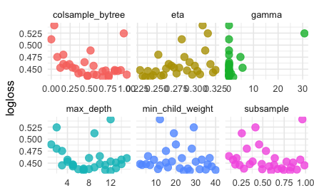

```r
results_train %>%
  select(logloss, eta, gamma, subsample, colsample_bytree, max_depth, min_child_weight) %>% #
  pivot_longer(eta:min_child_weight,
               values_to = "value",
               names_to = "parameter"
  ) %>%
  ggplot(aes(value, logloss, color = parameter)) +
  geom_point(alpha = 0.8, show.legend = FALSE, size = 3) +
  facet_wrap(~parameter, scales = "free_x") +
  labs(x = NULL, y = "logloss") +
  theme_minimal()
```

Above, we can see the results from the hyperparameter tuning. The key here is to look for patterns in the logloss and make sure that we covered the hyperparameter space as well as possible and don’t have to investigate further. It seems as though we have done that.

*XGBoost Model Using the Tuned Hyperparameters*

```r
# best result from the hyperparameter tuning
tuned_rounds <- 57
tuned_params <- list(
    booster = "gbtree",
    objective = "multi:softprob",
    eval_metric = c("mlogloss"),
    num_class = 5,
    eta = 0.2350000,
    gamma = 1.740480e+00,
    max_depth = 12,
    min_child_weight = 24,
    subsample = 0.5981023,
    colsample_bytree = 0.68,
    nthread = 0
  )

final_model <- xgboost::xgboost(params = tuned_params, data = x_train, nrounds = tuned_rounds, early_stopping_rounds = 10)
```

*Predictions Using the Tuned Model*

```r
xgb.pred_v2 = predict(final_model, x_test, reshape=T)
xgb.pred_v2 = as.data.frame(xgb.pred_v2)
colnames(xgb.pred_v2) = levels(xgb_data$play_result)

xgb.pred_v2 <- xgb.pred_v2[, c(3, 4, 1, 5, 2)]

preds_v2 <- test
preds_v2$out.prob <- xgb.pred_v2[,1]
preds_v2$single.prob <- xgb.pred_v2[,2]
preds_v2$double.prob <- xgb.pred_v2[,3]
preds_v2$triple.prob <- xgb.pred_v2[,4]
preds_v2$hr.prob <- xgb.pred_v2[,5]

max_prob_v2 <- colnames(xgb.pred_v2)[apply(xgb.pred_v2,1,which.max)]

preds_v2$max.prob <- max_prob_v2

sum(preds_v2$max.prob == preds_v2$play_result) / nrow(preds_v2)
```

```
[1] 0.831446
```

The best performing hyperparameter-tuned model had an 83.14% accuracy on the test set, beating the baseline model by about 0.1%.

*Model Feature Importance*

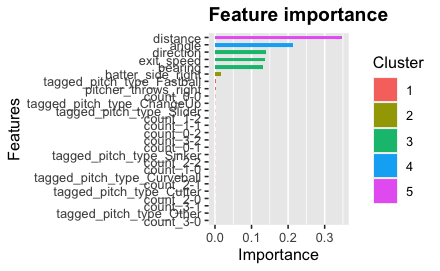

```r
importance <- xgboost::xgb.importance(feature_names = colnames(final_model), model = final_model)
xgboost::xgb.ggplot.importance(importance_matrix = importance)
```

Here we can see the feature importance of the final XGBoost model. Generally, feature importance provides a score that indicates how useful or valuable each feature was in the construction of the boosted decision trees within the model. The more an attribute is used to make key decisions with the decision trees, the higher its relative importance. From the results above, it is clear that distance was the most important feature in modeling the outcome of the play result. Inherently, that makes a lot of sense. It’s really hard to hit a homerun that goes five feet or hit a single that goes 450 feet. Following distance are the four other batted ball characteristics: angle, direction, exit speed, and bearing. Initially, I thought those five features would be the most influential in a model that aims to predict the play result and that was true.

# Validation

After figuring out what the best performing model on the test set was, I applied that model to the entire dataset to begin making my quality of contact metric.

*Using Best Peforming Model to Predict on Entire Dataset*

```r
vec_label_all_v2 <- xgb_data$play_result_ec
all_dataset_v2 <- as.matrix(xgb_data %>% dplyr::select(-c("pa_of_inning", "pitch_of_pa", "outs", "hit_type", "play_result", "play_result_ec",
                                                    "tagged_pitch_type", "count")))
full_dataset_v2 = xgb.DMatrix(data = all_dataset_v2, label = vec_label_all_v2)

xgb.pred_full_v2 = predict(final_model,full_dataset_v2,reshape=T)
xgb.pred_full_v2 = as.data.frame(xgb.pred_full_v2)
colnames(xgb.pred_full_v2) = levels(xgb_data$play_result)

xgb.pred_full_v2 <- xgb.pred_full_v2[, c(3, 4, 1, 5, 2)]

full_preds_v2 <- xgb_data
full_preds_v2$out.prob <- xgb.pred_full_v2[,1]
full_preds_v2$single.prob <- xgb.pred_full_v2[,2]
full_preds_v2$double.prob <- xgb.pred_full_v2[,3]
full_preds_v2$triple.prob <- xgb.pred_full_v2[,4]
full_preds_v2$hr.prob <- xgb.pred_full_v2[,5]

max_prob_full_preds <- colnames(xgb.pred_full_v2)[apply(xgb.pred_full_v2,1,which.max)]

full_preds_v2$max.prob <- max_prob_full_preds

full_preds_v2$pred.right <- ifelse(full_preds_v2$max.prob == full_preds_v2$play_result, "yes", "no")
full_preds_v2$pred.right <- as.factor(full_preds_v2$pred.right)

sum(full_preds_v2$max.prob == full_preds_v2$play_result) / nrow(full_preds_v2)
```

```
[1] 0.8513066
```

The accuracy of the final model applied to the entire dataset was 85.13%.

```r
full_preds_v2 %>%
  group_by(play_result, pred.right) %>%
  summarise(num = n()) %>%
  arrange(desc(num))
```

| play_result | pred.right | num |
| --- | --- | --- |
| Out | yes | 69822 |
| Single | yes | 16930 |
| Single | no | 7811 |
| HomeRun | yes | 6044 |
| Double | yes | 4933 |
| Out | no | 4654 |
| Double | no | 3311 |
| Triple | no | 758 |
| HomeRun | no | 536 |
| Triple | yes | 1 |

From the chart above, we can see that the model had the hardest time correctly predicting triples, only getting 1/759 correct. Triples tend to have similar batted ball characteristics of both singles and doubles and triples mainly happen because of defender positioning, which we don’t have in this dataset. For example, I mostly see triples hit into the outfield corners and the corner outfielder may be out of position or had a hard time getting to the ball and because of that the batter was able to reach third.

# QC+ Metric Creation

After using the best performing model to obtain predictions for each observation, I created my metric, Quality of Contact Plus (QC+). To generate QC+ values, I take the weighted on-base average (wOBA) linear weights for a single, double, triple, and homerun averaged over the last six seasons (2015-2020) and multiply those values by the probability of each batted ball belonging to each class. For example, say the model returned the probability of a batted ball belonging to the out class as 0.75, a single 0.20, and a double .05. I then multiplied those values by the corresponding wOBA values. For my example that would be (0 * .75) + (.878167 * .20) + (1.23867 * .05) = 0.2375669. Here the wOBA value for a single is .878167 and double 1.23867. This process returns a weighted likelihood value. I then took all of the weighted likelihoods and scaled them to a mean of 100 with a standard deviation of 30. I picked 100 as the mean to make my QC+ metric similar to publicly available metrics such as wRC+, OPS+, DRC+, and others. I selected a standard deviation of 30 because the standard deviation for wRC+ in 2019 was 29.64 and it made sense to calibrate it to a similar scale.

```r
woba_weights_2015_2020_avg <- c(0, .878167, 1.23867, 1.5633, 2.00167) # from FanGraphs

full_preds_v2 %<>%
  mutate(prob_times_woba_weight = (out.prob * woba_weights_2015_2020_avg[1]) + (single.prob * woba_weights_2015_2020_avg[2]) +
           (double.prob * woba_weights_2015_2020_avg[3]) + (triple.prob * woba_weights_2015_2020_avg[4]) +
           (hr.prob * woba_weights_2015_2020_avg[5]))

full_preds_v2$percentile <- 100 * (scales::rescale(full_preds_v2$prob_times_woba_weight, to=c(0,1)))
full_preds_v2$qcp <- psych::rescale(full_preds_v2$percentile, mean = 100, sd = 30, df=F)
full_preds_v2$qcp_rd <- round(full_preds_v2$qcp)

full_preds_v2 <- full_preds_v2[, c(1:12, 35:45, 13:34)]

full_preds_v2_cleaned <- full_preds_v2[, c(1:23)]

head(full_preds_v2_cleaned)
```

| pa_of_inning | pitch_of_pa | outs | tagged_pitch_type | hit_type | play_result | exit_speed | angle | direction | distance | bearing | count | out.prob | single.prob | double.prob | triple.prob | hr.prob | max.prob | pred.right | prob_times_woba_weight | percentile | qcp | qcp_rd |
| --- | --- | --- | --- | --- | --- | --- | --- | --- | --- | --- | --- | --- | --- | --- | --- | --- | --- | --- | --- | --- | --- | --- |
| 1 | 1 | 0 | Fastball | FlyBall | Out | 97.59 | 37.44 | 22.93 | 357.86 | 32.90 | 0-0 | 0.37917632 | 0.003004375 | 0.03546655 | 0.026383502 | 0.5559692979 | HomeRun | no | 1.20068209 | 59.991229 | 148.35110 | 148 |
| 3 | 3 | 2 | ChangeUp | FlyBall | HomeRun | 106.43 | 22.34 | -0.55 | 406.45 | -11.34 | 1-1 | 0.06979682 | 0.011992533 | 0.35978183 | 0.075103715 | 0.4833251536 | HomeRun | yes | 1.54104951 | 77.018198 | 168.97643 | 169 |
| 2 | 5 | 1 | Fastball | FlyBall | Out | 101.62 | 33.26 | -10.41 | 365.32 | -9.54 | 2-2 | 0.95388538 | 0.001354659 | 0.02375941 | 0.008906456 | 0.0120940851 | Out | yes | 0.06875151 | 3.366106 | 79.75923 | 80 |
| 2 | 1 | 1 | Fastball | LineDrive | Out | 96.49 | 18.54 | 23.04 | 289.52 | 30.02 | 0-0 | 0.92131895 | 0.040794909 | 0.03118897 | 0.006043782 | 0.0006533500 | Out | yes | 0.08521362 | 4.189628 | 80.75679 | 81 |
| 2 | 4 | 1 | ChangeUp | GroundBall | Out | 87.40 | -3.42 | 42.64 | 20.21 | 36.39 | 1-2 | 0.96150810 | 0.020637065 | 0.01362616 | 0.004118453 | 0.0001102591 | Out | yes | 0.04166018 | 2.010855 | 78.11757 | 78 |
| 3 | 2 | 2 | Fastball | GroundBall | Single | 101.32 | 11.66 | -7.72 | 202.71 | -11.09 | 1-0 | 0.02000462 | 0.858117938 | 0.11970624 | 0.001902462 | 0.0002687605 | Single | yes | 0.90535948 | 45.217638 | 130.45537 | 130 |

Here’s an example of what the class probabilities and QC+ metric look like.

# A summary of your results, including any tables or charts, assessing the success rate of your model.

Below is a simple table showing the average QC+ for each hit type. This follows our intuition that line drives have the best outcomes and popups have the worst. It’s interesting to see, however, that bunts and ground balls have very similar average QC+.

```r
full_preds_v2_cleaned %>%
  group_by(hit_type) %>%
  summarise(num_BBEs = n(),
            avg_QC = mean(qcp)) %>%
  arrange(desc(avg_QC))
```

| hit_type | num_BBEs | avg_QC |
| --- | --- | --- |
| LineDrive | 30681 | 115.50954 |
| FlyBall | 28924 | 106.17651 |
| Undefined | 10 | 100.80332 |
| Bunt | 938 | 89.64597 |
| GroundBall | 48580 | 89.21053 |
| Popup | 5667 | 78.71168 |

In this diagram we can see the corresponding ‘hot’ spots for the QC+ metric. It’s important to note that here the x axis is the bearing of the batted ball and not the x-coordinate location. This is a great way to see QC+ validated. The fielder positions are placed based on the average location of each defender from the last five seasons, taken from baseballsavant.com. These positions correspond to the ‘cool’ zones of QC+. Focusing on the infield, we can see the hot zones in the gaps between the average location of the infielders. For example, to the left of third base and to the right of first base those would be singles, doubles, or triples, down the line getting past the respective defenders at their base. We can also see the gap between the infielders and outfielders where we would expect bloop singles or doubles falling in between the defenders. Also, the power alleys are visible between the corner outfielders and the centerfielder. Most notably, batted balls that are typical homerun distance are the brightest spots on the diamond. All of this comes together nicely to validate the success of my QC+ metric.

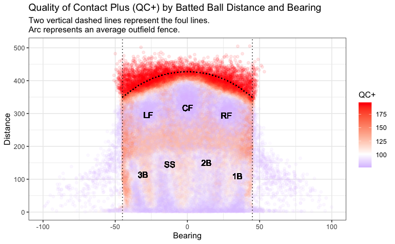

```r
ggplot(full_preds_v2_cleaned, aes(x = bearing, y = distance, color = qcp)) +
  geom_point(alpha = .1) +
  scale_color_gradient2(low = "blue", mid = "white", midpoint = 100, high = "red") +
  xlim(-100, 100) +
  geom_vline(xintercept = -45, color = "black", linetype = "dotted") + #third base line
  geom_vline(xintercept = 45, color = "black", linetype = "dotted") + #first base line
  geom_curve(x = -45, xend = 45, y = 350, yend = 350, curvature = -.4 ,linetype = "dotted", color = "black")+   # avg fence depth
  geom_text(aes(x = 34.6, y = 109.8, label = "1B"), color = "black") +
  geom_text(aes(x = 13.2, y = 149.8, label = "2B"), color = "black") +
  geom_text(aes(x=-12.2, y = 145.6, label = "SS"), color = "black") +
  geom_text(aes(x=-30.8, y = 114, label = "3B"), color = "black") +
  geom_text(aes(x=-27, y = 295.2, label = "LF"), color = "black") +
  geom_text(aes(x=.2, y = 318.4, label = "CF"), color = "black") +
  geom_text(aes(x=27, y = 293.8, label = "RF"), color = "black") +
  labs(y = "Distance", x = "Bearing", color = "QC+", title = "Quality of Contact Plus (QC+) by Batted Ball Distance and Bearing",
       subtitle = "Two vertical dashed lines represent the foul lines.\nArc represents an average outfield fence.") +
  theme_bw()
```

This next chart further validates the QC+ metric. We can see QC+ by the combination of exit speed and launch angle. This follows our basic intuition of what quality contact is: batted balls hit over 100 mph with a launch angle of around 20-45 degrees. We can also see a strip of batted balls that are in the typical range for falling in between fielders and harder hit doubles, just below the typical homerun combination. Slower hit balls need a higher launch angle to land for a hit and then we can see as the exit speed increases the launch angle then decreases showing that harder hit balls can’t be hit as high as bloopers.

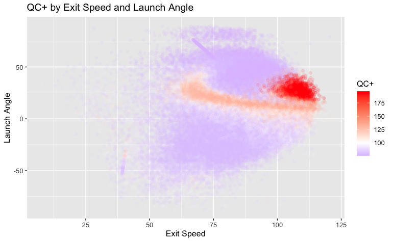

```r
ggplot(full_preds_v2_cleaned, aes(x = exit_speed, y = angle, color = qcp)) +
  geom_point(alpha = .1) +
  scale_color_gradient2(low = "blue", mid = "white", midpoint = 100, high = "red") +
  labs(x = "Exit Speed", y = "Launch Angle", title = "QC+ by Exit Speed and Launch Angle", color = "QC+")
```